# Explore_bikeshare_data

### Explore Bike Share Data

For this project, your goal is to ask and answer three questions about the available bikeshare data from Washington, Chicago, and New York. This notebook can be submitted directly through the workspace when you are confident in your results.

You will be graded against the project [Rubric](https://review.udacity.com/#!/rubrics/2508/view) by a mentor after you have submitted. To get you started, you can use the template below, but feel free to be creative in your solutions!

```r
library(ggplot2)
```

```r
ny = read.csv('new_york_city.csv')
wash = read.csv('washington.csv')
chi = read.csv('chicago.csv')
```

```r
head(ny)
```

| X | Start.Time | End.Time | Trip.Duration | Start.Station | End.Station | User.Type | Gender | Birth.Year |
| --- | --- | --- | --- | --- | --- | --- | --- | --- |
| 5688089 | 2017-06-11 14:55:05 | 2017-06-11 15:08:21 | 795 | Suffolk St & Stanton St | W Broadway & Spring St | Subscriber | Male | 1998 |
| 4096714 | 2017-05-11 15:30:11 | 2017-05-11 15:41:43 | 692 | Lexington Ave & E 63 St | 1 Ave & E 78 St | Subscriber | Male | 1981 |
| 2173887 | 2017-03-29 13:26:26 | 2017-03-29 13:48:31 | 1325 | 1 Pl & Clinton St | Henry St & Degraw St | Subscriber | Male | 1987 |
| 3945638 | 2017-05-08 19:47:18 | 2017-05-08 19:59:01 | 703 | Barrow St & Hudson St | W 20 St & 8 Ave | Subscriber | Female | 1986 |
| 6208972 | 2017-06-21 07:49:16 | 2017-06-21 07:54:46 | 329 | 1 Ave & E 44 St | E 53 St & 3 Ave | Subscriber | Male | 1992 |
| 1285652 | 2017-02-22 18:55:24 | 2017-02-22 19:12:03 | 998 | State St & Smith St | Bond St & Fulton St | Subscriber | Male | 1986 |

```r
head(wash)
```

| X | Start.Time | End.Time | Trip.Duration | Start.Station | End.Station | User.Type |
| --- | --- | --- | --- | --- | --- | --- |
| 1621326 | 2017-06-21 08:36:34 | 2017-06-21 08:44:43 | 489.066 | 14th & Belmont St NW | 15th & K St NW | Subscriber |
| 482740 | 2017-03-11 10:40:00 | 2017-03-11 10:46:00 | 402.549 | Yuma St & Tenley Circle NW | Connecticut Ave & Yuma St NW | Subscriber |
| 1330037 | 2017-05-30 01:02:59 | 2017-05-30 01:13:37 | 637.251 | 17th St & Massachusetts Ave NW | 5th & K St NW | Subscriber |
| 665458 | 2017-04-02 07:48:35 | 2017-04-02 08:19:03 | 1827.341 | Constitution Ave & 2nd St NW/DOL | M St & Pennsylvania Ave NW | Customer |
| 1481135 | 2017-06-10 08:36:28 | 2017-06-10 09:02:17 | 1549.427 | Henry Bacon Dr & Lincoln Memorial Circle NW | Maine Ave & 7th St SW | Subscriber |
| 1148202 | 2017-05-14 07:18:18 | 2017-05-14 07:24:56 | 398.000 | 1st & K St SE | Eastern Market Metro / Pennsylvania Ave & 7th St SE | Subscriber |

```r
head(chi)
```

| X | Start.Time | End.Time | Trip.Duration | Start.Station | End.Station | User.Type | Gender | Birth.Year |
| --- | --- | --- | --- | --- | --- | --- | --- | --- |
| 1423854 | 2017-06-23 15:09:32 | 2017-06-23 15:14:53 | 321 | Wood St & Hubbard St | Damen Ave & Chicago Ave | Subscriber | Male | 1992 |
| 955915 | 2017-05-25 18:19:03 | 2017-05-25 18:45:53 | 1610 | Theater on the Lake | Sheffield Ave & Waveland Ave | Subscriber | Female | 1992 |
| 9031 | 2017-01-04 08:27:49 | 2017-01-04 08:34:45 | 416 | May St & Taylor St | Wood St & Taylor St | Subscriber | Male | 1981 |
| 304487 | 2017-03-06 13:49:38 | 2017-03-06 13:55:28 | 350 | Christiana Ave & Lawrence Ave | St. Louis Ave & Balmoral Ave | Subscriber | Male | 1986 |
| 45207 | 2017-01-17 14:53:07 | 2017-01-17 15:02:01 | 534 | Clark St & Randolph St | Desplaines St & Jackson Blvd | Subscriber | Male | 1975 |
| 1473887 | 2017-06-26 09:01:20 | 2017-06-26 09:11:06 | 586 | Clinton St & Washington Blvd | Canal St & Taylor St | Subscriber | Male | 1990 |

```r
names(ny)
```

1. 'X'

2. 'Start.Time'

3. 'End.Time'

4. 'Trip.Duration'

5. 'Start.Station'

6. 'End.Station'

7. 'User.Type'

8. 'Gender'

9. 'Birth.Year'

```r
names(chi)
```

1. 'X'

2. 'Start.Time'

3. 'End.Time'

4. 'Trip.Duration'

5. 'Start.Station'

6. 'End.Station'

7. 'User.Type'

8. 'Gender'

9. 'Birth.Year'

```r
names(wash)
```

1. 'X'

2. 'Start.Time'

3. 'End.Time'

4. 'Trip.Duration'

5. 'Start.Station'

6. 'End.Station'

7. 'User.Type'

```r
#added ny and chicago
all<-rbind(ny,chi)
```

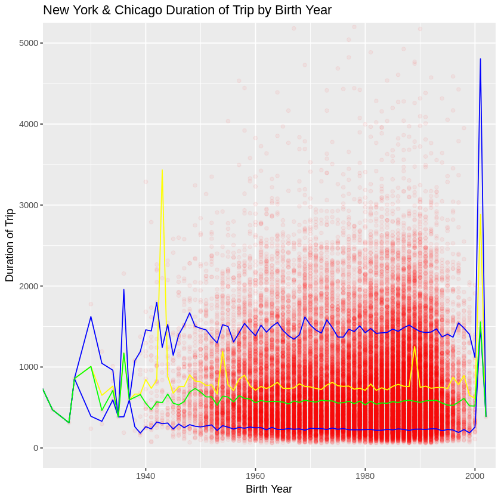

```r
ggplot(aes(x=all$Birth.Year, y=all$Trip.Duration),data=all) +
  geom_point(alpha=(0.05),color='red')+
  labs(x="Birth Year",y="Duration of Trip",title="New York & Chicago Duration of Trip by Birth Year")+
  coord_cartesian(ylim=c(0,5000),xlim=c(1925,2000))+
  geom_line(stat='summary',fun.y="mean", color = 'yellow')+
  geom_line(stat = 'summary', fun.y = "quantile", fun.args = list(probs = .1), color = 'blue') +
  geom_line(stat = 'summary', fun.y = "quantile", fun.args = list(probs = .9), color = 'blue') +
  geom_line(stat = 'summary', fun.y = "quantile", fun.args = list(probs = .5), color = 'green')
```

```
Warning message:
“Removed 6965 rows containing non-finite values (stat_bin).”
```

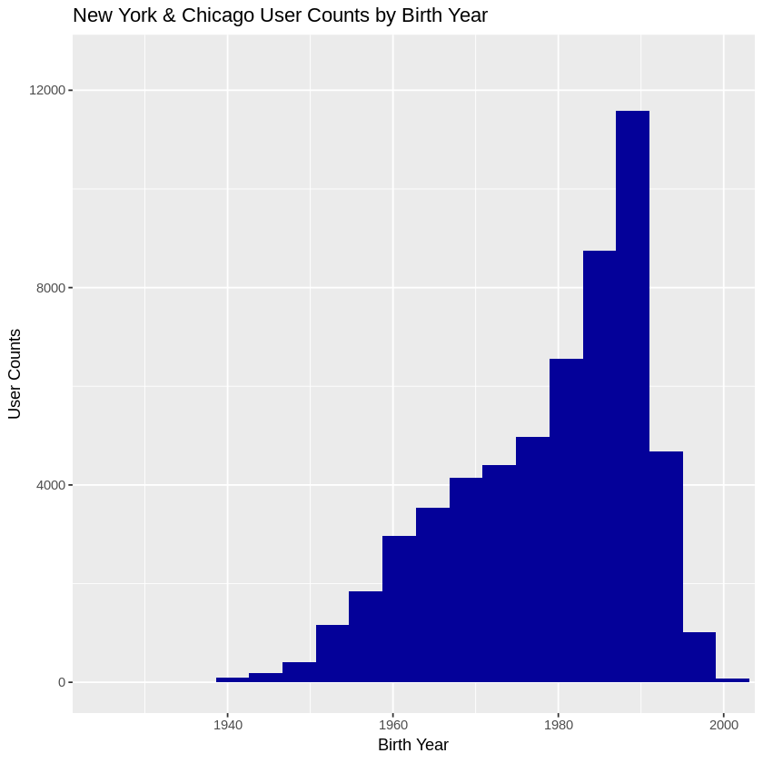

```r
#User counts by Birth year
ggplot(aes(x=all$Birth.Year),data=all) +
  geom_histogram(fill="#040199")+
  labs(x="Birth Year",y="User Counts",title="New York & Chicago User Counts by Birth Year")+
  coord_cartesian(ylim=c(0,12500),xlim=c(1925,2000))
```

### Question 1

What is the average trip duration in each city?

```r
#Use summary to double check that the mean is calulated properly
summary(ny$Trip.Duration)
```

```
     Min.   1st Qu.    Median      Mean   3rd Qu.      Max.      NA's
     61.0     368.0     610.0     903.6    1051.0 1088634.0         1
```

```r
# saving the mean to a variable
nymean <- mean(x=ny$Trip.Duration, na.rm=TRUE)
nymean
```

903.614690792237

```r
#Use summary to double check that the mean is calulated properly
summary(chi$Trip.Duration)
```

```
   Min. 1st Qu.  Median    Mean 3rd Qu.    Max.
   60.0   394.2   670.0   937.2  1119.0 85408.0
```

```r
# saving the mean to a variable
chimean<- mean(x=chi$Trip.Duration, na.rm=TRUE)
chimean
```

937.172769409038

```r
#Use summary to double check that the mean is calulated properly
summary(wash$Trip.Duration, na.rm=TRUE)
```

```
    Min.  1st Qu.   Median     Mean  3rd Qu.     Max.     NA's
    60.3    410.9    707.0   1234.0   1233.2 904591.4        1
```

```r
# saving the mean to a variable
washmean <- mean(x=wash$Trip.Duration, na.rm=TRUE)
washmean
```

1233.95333709152

```r
#creating a dataframe of city means
dfcitymeans <- data.frame(city=c("New York", "Washington", "Chicago"),
                citymeans=c(nymean, washmean, chimean))
head(dfcitymeans)
```

| city | citymeans |
| --- | --- |
| New York | 903.6147 |
| Washington | 1233.9533 |
| Chicago | 937.1728 |

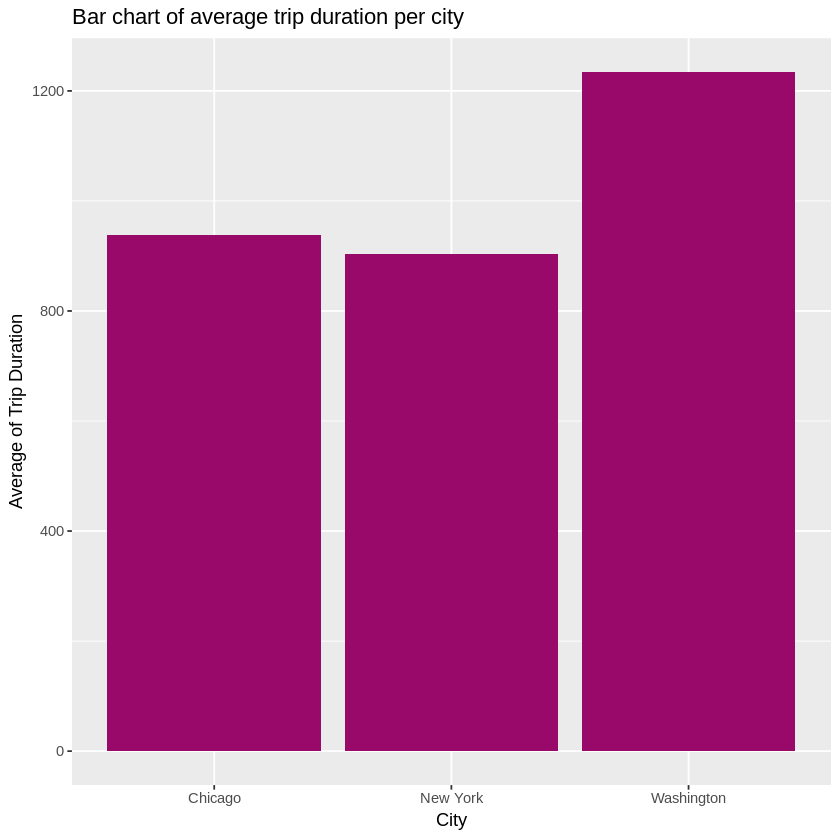

```r
#creating a bar chart using ggplot for the means of trip duration per city
p<-ggplot(data=dfcitymeans, aes(x=city, y=citymeans)) +
  geom_bar(stat="identity", fill=("#990969")) +
  labs(x="City", y="Average of Trip Duration") +
  ggtitle("Bar chart of average trip duration per city")
p
```

It seems like people in Washington had a higher trip duration as compared to Chicago and New York. New York and Chicago seemed to have similar trip durations. I felt like a bar chart was the most appropriate way to compare these since we were finding the means of the trip duration for each city.

### Question 2

What is are the most commonly used stations for each city?

```r
#started with a function to find the most common station for each city
#create a function to find the most common value in a column
findMcommon=function(val=0){
    #create a table of values
    a <- table(val)
    #sort that table
    b <-sort(a)
    #find the last value in the sorted table
    c <-b[length(b)]
    #return that value
    return(c)
}
```

```r
tableOfTopStations=function(val=0, name="",type=""){
    #create a table of values
    a <- table(val)
    b <-sort(a)
    if (length(b) >=10){
        c <-data.frame ( Station.Name = c(rownames(b)[length(b)],
                                         rownames(b)[length(b)-1],
                                         rownames(b)[length(b)-2],
                                         rownames(b)[length(b)-3],
                                         rownames(b)[length(b)-4]),
                  Number.Of.Users = c(b[length(b)],
                                      b[(length(b)-1)],
                                      b[(length(b)-2)],
                                      b[(length(b)-3)],
                                      b[(length(b)-4)]),
                  Originating.From = c(name,name,name,name,name),
                  Data.Type = c(type,type,type,type,type)
                  )
    } else {
        return(0)
    }
    return(c)
}
```

```r
nyStarting<-tableOfTopStations(ny$Start.Station, "New York","Starting")
```

```r
nyEnding<-tableOfTopStations(ny$End.Station, "New York","Ending")
```

```r
nyTotal<-rbind(nyStarting,nyEnding)
nyTotal
```

|  | Station.Name | Number.Of.Users | Originating.From | Data.Type |
| --- | --- | --- | --- | --- |
| Pershing Square North | Pershing Square North | 592 | New York | Starting |
| W 21 St & 6 Ave | W 21 St & 6 Ave | 385 | New York | Starting |
| Broadway & E 22 St | Broadway & E 22 St | 383 | New York | Starting |
| E 17 St & Broadway | E 17 St & Broadway | 380 | New York | Starting |
| West St & Chambers St | West St & Chambers St | 364 | New York | Starting |
| Pershing Square North1 | Pershing Square North | 556 | New York | Ending |
| E 17 St & Broadway1 | E 17 St & Broadway | 445 | New York | Ending |
| Broadway & E 22 St1 | Broadway & E 22 St | 427 | New York | Ending |
| W 21 St & 6 Ave1 | W 21 St & 6 Ave | 365 | New York | Ending |
| W 20 St & 11 Ave | W 20 St & 11 Ave | 344 | New York | Ending |

```r
chiStarting<-tableOfTopStations(chi$Start.Station, "Chicago","Starting")
```

```r
chiEnding<-tableOfTopStations(chi$End.Station, "Chicago","Ending")
```

```r
chiTotal<-rbind(chiStarting,chiEnding)
chiTotal
```

|  | Station.Name | Number.Of.Users | Originating.From | Data.Type |
| --- | --- | --- | --- | --- |
| Streeter Dr & Grand Ave | Streeter Dr & Grand Ave | 210 | Chicago | Starting |
| Lake Shore Dr & Monroe St | Lake Shore Dr & Monroe St | 140 | Chicago | Starting |
| Clinton St & Washington Blvd | Clinton St & Washington Blvd | 120 | Chicago | Starting |
| Clinton St & Madison St | Clinton St & Madison St | 102 | Chicago | Starting |
| Canal St & Adams St | Canal St & Adams St | 101 | Chicago | Starting |
| Streeter Dr & Grand Ave1 | Streeter Dr & Grand Ave | 233 | Chicago | Ending |
| Clinton St & Madison St1 | Clinton St & Madison St | 145 | Chicago | Ending |
| Theater on the Lake | Theater on the Lake | 131 | Chicago | Ending |
| Lake Shore Dr & Monroe St1 | Lake Shore Dr & Monroe St | 115 | Chicago | Ending |
| Clinton St & Washington Blvd1 | Clinton St & Washington Blvd | 109 | Chicago | Ending |

```r
washStarting<-tableOfTopStations(wash$Start.Station, "Washington","Starting")
```

```r
washEnding<-tableOfTopStations(wash$End.Station, "Washington","Ending")
```

```r
washTotal<-rbind(washStarting,washEnding)
washTotal
```

|  | Station.Name | Number.Of.Users | Originating.From | Data.Type |
| --- | --- | --- | --- | --- |
| Columbus Circle / Union Station | Columbus Circle / Union Station | 1700 | Washington | Starting |
| Lincoln Memorial | Lincoln Memorial | 1546 | Washington | Starting |
| Jefferson Dr & 14th St SW | Jefferson Dr & 14th St SW | 1488 | Washington | Starting |
| Massachusetts Ave & Dupont Circle NW | Massachusetts Ave & Dupont Circle NW | 1219 | Washington | Starting |
| Jefferson Memorial | Jefferson Memorial | 1068 | Washington | Starting |
| Columbus Circle / Union Station1 | Columbus Circle / Union Station | 1767 | Washington | Ending |
| Jefferson Dr & 14th St SW1 | Jefferson Dr & 14th St SW | 1603 | Washington | Ending |
| Lincoln Memorial1 | Lincoln Memorial | 1514 | Washington | Ending |
| Massachusetts Ave & Dupont Circle NW1 | Massachusetts Ave & Dupont Circle NW | 1344 | Washington | Ending |
| Smithsonian-National Mall / Jefferson Dr & 12th St SW | Smithsonian-National Mall / Jefferson Dr & 12th St SW | 1103 | Washington | Ending |

```r
#Most common start station for NY
NY.Start.Station<-findMcommon(ny$Start.Station)
NY.Start.Station
```

**Pershing Square North:** 592

```r
#Most common start station for Chicago
Chicago.Start.Station<-findMcommon(chi$Start.Station)
Chicago.Start.Station
```

**Streeter Dr & Grand Ave:** 210

```r
#Most common start station for Washington
Washington.Start.Station<-findMcommon(wash$Start.Station)
Washington.Start.Station
```

**Columbus Circle / Union Station:** 1700

```r
#Most common end station for NY
NY.End.Station<-findMcommon(ny$End.Station)
NY.End.Station
```

**Pershing Square North:** 556

```r
#Most common end station for Chicago
Chicago.End.Station<-findMcommon(chi$End.Station)
Chicago.End.Station
```

**Streeter Dr & Grand Ave:** 233

```r
#Most common end station for Washington
Washington.End.Station<-findMcommon(wash$End.Station)
Washington.End.Station
```

**Columbus Circle / Union Station:** 1767

```r
#Built a dataframe for NY start and end stations
NY.Stations<-cbind(NY.Start.Station,NY.End.Station)
NY.Stations
```

|  | NY.Start.Station | NY.End.Station |
| --- | --- | --- |
| Pershing Square North | 592 | 556 |

```r
#Built a dataframe for start and end Chicago stations
Chicago.Stations<-cbind(Chicago.Start.Station,Chicago.End.Station)
Chicago.Stations
```

|  | Chicago.Start.Station | Chicago.End.Station |
| --- | --- | --- |
| Streeter Dr & Grand Ave | 210 | 233 |

```r
#Built a dataframe for Washington start and end stations
Washington.Stations<-cbind(Washington.Start.Station,Washington.End.Station)
Washington.Stations
```

|  | Washington.Start.Station | Washington.End.Station |
| --- | --- | --- |
| Columbus Circle / Union Station | 1700 | 1767 |

```r
nyStart<-tableOfTopStations(ny$Start.Station)
```

```r
nyTopStart<-tableOfTopStations(ny$Start.Station)
```

```r
nyTopEnd<-tableOfTopStations(ny$End.Station)
```

```r
nyTopStart
```

|  | Station.Name | Number.Of.Users | Originating.From | Data.Type |
| --- | --- | --- | --- | --- |
| Pershing Square North | Pershing Square North | 592 |  |  |
| W 21 St & 6 Ave | W 21 St & 6 Ave | 385 |  |  |
| Broadway & E 22 St | Broadway & E 22 St | 383 |  |  |
| E 17 St & Broadway | E 17 St & Broadway | 380 |  |  |
| West St & Chambers St | West St & Chambers St | 364 |  |  |

```r
nyTopStart$Station.Name
```

1. Pershing Square North

2. W 21 St & 6 Ave

3. Broadway & E 22 St

4. E 17 St & Broadway

5. West St & Chambers St

**Levels**:**

1. 'Broadway & E 22 St'

2. 'E 17 St & Broadway'

3. 'Pershing Square North'

4. 'W 21 St & 6 Ave'

5. 'West St & Chambers St'

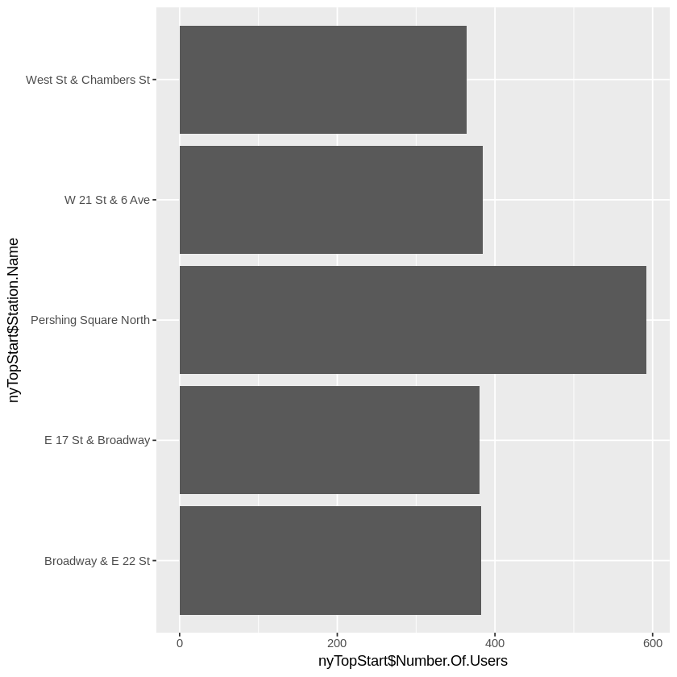

```r
ggplot(aes(x=nyTopStart$Station.Name, y=nyTopStart$Number.Of.Users),data=nyTopStart) +
  geom_bar(stat="identity") +
  coord_flip()
```

```r
names(nyTotal)
```

1. 'Station.Name'

2. 'Number.Of.Users'

3. 'Originating.From'

4. 'Data.Type'

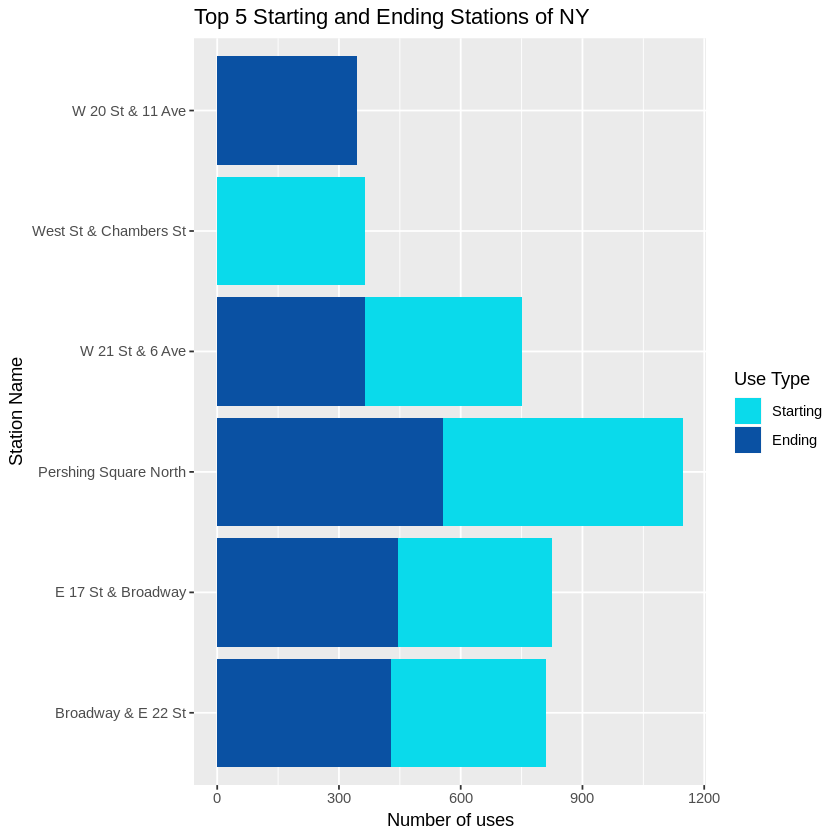

```r
ggplot(nyTotal, aes(x = nyTotal$Station.Name, y=nyTotal$Number.Of.Users, fill = nyTotal$Data.Type)) +
    geom_bar(stat="identity") +
    coord_flip()+
    labs(x="Station Name", y="Number of uses", title="Top 5 Starting and Ending Stations of NY")+
    guides(fill = guide_legend(title="Use Type")) +
    scale_fill_manual(values = c("#0ADAEB", "#0A51A3"))
```

```r
names(ny)
```

1. 'X'

2. 'Start.Time'

3. 'End.Time'

4. 'Trip.Duration'

5. 'Start.Station'

6. 'End.Station'

7. 'User.Type'

8. 'Gender'

9. 'Birth.Year'

```r
tableOfTopStations=function(val=0, name="",type=""){
    #create a table of values
    a <- table(val)
    b <-sort(a)
    if (length(b) >=10){
        c <-data.frame ( Station.Name = c(rownames(b)[length(b)],
                                         rownames(b)[length(b)-1],
                                         rownames(b)[length(b)-2],
                                         rownames(b)[length(b)-3],
                                         rownames(b)[length(b)-4]),
                  Number.Of.Users = c(b[length(b)],
                                      b[(length(b)-1)],
                                      b[(length(b)-2)],
                                      b[(length(b)-3)],
                                      b[(length(b)-4)]),
                  Originating.From = c(name,name,name,name,name),
                  Data.Type = c(type,type,type,type,type)
                  )
    } else {
        return(0)
    }
    return(c)
}
```

```r
tableVarTopStations=function(val=0, name="",type="",num=5){
    #create a table of values
    a <- table(val)
    b <-sort(a)
    count=0
    while (count <num){
        c <-data.frame ( Station.Name = c(rownames(b)[length(b)],
                                         rownames(b)[length(b)-1],
                                         rownames(b)[length(b)-2],
                                         rownames(b)[length(b)-3],
                                         rownames(b)[length(b)-4]),
                  Number.Of.Users = c(b[length(b)],
                                      b[(length(b)-1)],
                                      b[(length(b)-2)],
                                      b[(length(b)-3)],
                                      b[(length(b)-4)]),
                  Originating.From = c(name,name,name,name,name),
                  Data.Type = c(type,type,type,type,type)
                  )
        count=count+1
    }
    return(c)
}
```

```r
tableVarTopStations(ny$Start.Station)
```

|  | Station.Name | Number.Of.Users | Originating.From | Data.Type |
| --- | --- | --- | --- | --- |
| Pershing Square North | Pershing Square North | 592 |  |  |
| W 21 St & 6 Ave | W 21 St & 6 Ave | 385 |  |  |
| Broadway & E 22 St | Broadway & E 22 St | 383 |  |  |
| E 17 St & Broadway | E 17 St & Broadway | 380 |  |  |
| West St & Chambers St | West St & Chambers St | 364 |  |  |